# 2_Comparing_means_of_two_groups

### Further Hypothesis Testing

```python
# Select this cell and type Ctrl-Enter to execute the code below.

import numpy as np
import pandas as pd
from scipy import stats
import matplotlib.pyplot as plt

data = pd.read_csv("stars.csv")
type_key = ['Brown Dwarf', 'Red Dwarf', 'White Dwarf', 'Main Sequence', 'Supergiant','Hypergiant']
```

## 2 - Comparing means of two groups

For now, let's look at only types 4 and 5 (supergiant and hypergiant). These are of particular interest to your supervisor, Dr Howe.

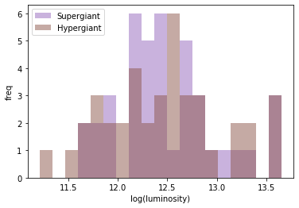

```python
types = [4,5]

sample = data.luminosity.apply(np.log)
grouped = sample.groupby(data.type)

xlab = 'log(luminosity)'
ylab = 'freq'

displayed = pd.concat([grouped.get_group(t) for t in types])
bins = np.linspace(displayed.min(), displayed.max(), 20)
ax = plt.axes()
ax.set_xlabel(xlab)
ax.set_ylabel(ylab)

plt.hist(grouped.get_group(types[0]), bins, alpha=0.5, label=type_key[types[0]], color='C' + str(types[0]))
plt.hist(grouped.get_group(types[1]), bins, alpha=0.5, label=type_key[types[1]], color='C' + str(types[1]))

ax.legend(loc='upper left')
plt.show()
```

Dr Howe has noticed that supergiants and hypergiants seem to have very similar luminosity distributions. She asks you to check whether they have the same mean.

### Question: do types 4 and 5 have the same mean luminosity?

The sample means of log(luminosity) are easy to obtain:

```python
type4 = data[data.type == 4].luminosity.apply(np.log)
type5 = data[data.type == 5].luminosity.apply(np.log)

mean4 = type4.mean()
mean5 = type5.mean()

print('Type 4:', mean4)
print('Type 5:', mean5)
print('difference:', mean4 - mean5)
```

```
Type 4: 12.484801172794501
Type 5: 12.46505793769327
difference: 0.019743235101230994
```

They are certainly very similar, but is the difference between them statistically significant?

From the histogram, both distributions of log(luminosity) seem approximately symmetrical and with a rough bell-curve, so for now we will assume that they are normally distributed. (We will look later at how to test for normality.)

We can therefore choose a **parametric test** for the difference between two means. This means that the test uses a defined probability distribution (e.g. the normal distribution) as a model for the process that generates the data.

In general, if the assumptions of a parametric test are satisfied then it will provide more **statistical power** than a non-parametric alternative. Statistical power is defined as the probability that the test *correctly rejects the null hypothesis when it is false*, also known as its *sensitivity* or *true positive rate*.

Different parametric test make different **assumptions** about the data, so it is important to think carefully about whether these are satisfied before deciding on a particular test.

In this example, a [*t-test*](https://en.wikipedia.org/wiki/Student%27s_t-test) is appropriate:

### t-test for 2 independent groups

#### Theory

When comparing two samples (1 and 2), we will refer to their sizes as $n_1$ and $n_2$, their sample means as $\bar{x}_1$ and $\bar{x}_2$ and their sample standard deviations as $s_1$ and $s_2$.

Recall that

$$\bar{x} = \frac{\sum_{i=1}^n x_i}{n}$$

is the *sample mean*

and

$$s^2 = \frac{\sum_{i=1}^n (x_i - \bar{x})^2}{n-1}$$

is the *unbiased sample variance*.

For our example, we need a two-tailed test:

$H_0$: The two samples come from the same distribution with mean $\mu = \mu_1 = \mu_2$.

$H_1$: The samples come from two different distributions, with means $\mu_1 \ne \mu_2$.

The test statistic is given by

$$t = \frac{\bar {x}_1 - \bar{x}_2}{s_p \cdot \sqrt{\frac{1}{n_1}+\frac{1}{n_2}}}$$

,

where

$$s_p^2 = \frac{\left(n_1-1\right)s_1^2 + \left(n_2-1\right)s_2^2}{n_1 + n_2-2}$$

is an unbiased estimator of the *pooled variance* of the two samples.

Under $H_0$, the test statistic $t$ follows a *Student's t-distribution* with $n_1 + n_2 - 2$ degrees of freedom.

We use this distribution to calculate a p-value for the observed value of the test statistic, $t$.

#### Assumptions

- The means of the two samples follow normal distributions. This is true if the samples themselves are normal, but also true for any other distribution if $n$ is large (by the *central limit theorem*).
- The two populations have equal variance.
- The two samples are independent.

Two-sample t-tests are robust to moderate deviations from these assumptions, but major deviations may produce misleading results.

#### Application

$H_0$: $\mu_{\text{type4}} = \mu_{\text{type5}}$.

$H_1$: $\mu_{\text{type4}} \ne \mu_{\text{type5}}$.

Let's set a significance level $\alpha=0.05$

Using a statistical library such as `scipy.stats`, we just supply the data for each sample and the test function deals with the rest:

```python
stats.ttest_ind(type4, type5)
```

```
Ttest_indResult(statistic=0.1602081489993176, pvalue=0.8731312842604647)
```

We can visualise this result on the t-distribution:

```
degrees of freedom: 78
```

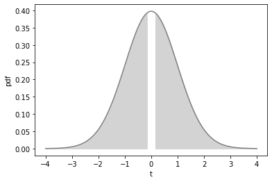

```python
t_obs = stats.ttest_ind(type4, type5).statistic
df = len(type4) + len(type5) - 2
print("degrees of freedom:", df)

tmin = -4
tmax = 4

t = stats.t(df)
x = np.linspace(tmin,tmax,100)
ax = plt.axes()
ax.set_xlabel("t")
ax.set_ylabel("pdf")
plt.plot(x, t.pdf(x), color='gray')

# the area of the shaded region is the two-tailed p-value
lower_tail = np.linspace(tmin,-t_obs,100)
upper_tail = np.linspace(t_obs,tmax,100)
plt.fill_between(lower_tail,t.pdf(lower_tail),color='lightgrey')
plt.fill_between(upper_tail,t.pdf(upper_tail),color='lightgrey')
plt.show()
```

The t-test p-value is greater than than $\alpha$, so we accept the null hypothesis that the means are equal.

### Other types of t-test

#### One-tailed t-test

In the example above, we used a *two-tailed test* (because $H_1:\mu_1 \ne \mu_2$ was symmetrical).

For a *one-tailed test*, we need to halve the two-sided p-value, e.g.

$H_1:\mu_{\text{type4}}>\mu_{\text{type5}}$ would give us

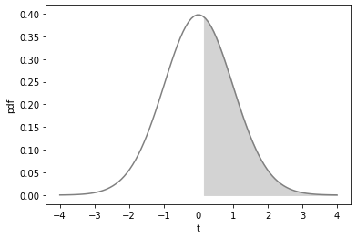

```python
ax = plt.axes()
ax.set_xlabel("t")
ax.set_ylabel("pdf")
plt.plot(x, t.pdf(x), color='gray')

# the area of the shaded region is the one-tailed p-value for H1: mu_1 > mu_2
upper_tail = np.linspace(t_obs,tmax,100)
plt.fill_between(upper_tail,t.pdf(upper_tail),color='lightgrey')
plt.show()
```

```python
p_2tailed = stats.ttest_ind(type4, type5).pvalue
p_1tailed = p_2tailed/2
print('1-tailed p-value:', p_1tailed)
```

```
1-tailed p-value: 0.43656564213023236
```

To test the complementary hypothesis (i.e. $H_1:\mu_1<\mu_2$), we would need to use `1 - p_1tailed`, e.g.

$H_1:\mu_{\text{type4}}<\mu_{\text{type5}}$ would give us

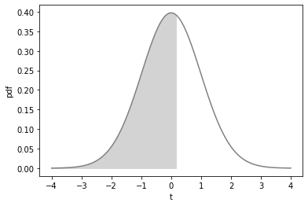

```python
ax = plt.axes()
ax.set_xlabel("t")
ax.set_ylabel("pdf")
plt.plot(x, t.pdf(x), color='gray')

# the area of the shaded region is the one-tailed p-value for H1: mu_1 < mu_2
lower_tail = np.linspace(tmin,t_obs,100)
plt.fill_between(lower_tail,t.pdf(lower_tail),color='lightgrey')
plt.show()
```

```python
p_2tailed = stats.ttest_ind(type5, type4).pvalue
p_1tailed = p_2tailed/2
print('1-tailed p-value:', 1 - p_1tailed)
```

```
1-tailed p-value: 0.5634343578697676
```

#### Paired two-sample t-test

Sometimes we have two samples with paired observations (for example, luminosity of the same set of stars, as measured on two different dates). This situation requires testing whether the *mean of the differences* between pairs is zero, which is called a [*paired two-sample t-test*](https://en.wikipedia.org/wiki/Student%27s_t-test#Dependent_t-test_for_paired_samples).

#### Welch's t-test

If the sample sizes in the two groups being compared are equal, Student's original t-test is highly robust to the presence of unequal variances. [*Welch's t-test*](https://en.wikipedia.org/wiki/Welch%27s_t-test) is an alternative that is insensitive to equality of the variances, regardless of whether the sample sizes are similar.

#### One-sample t-test

For cases where we want to compare a sample against a theoretical mean, we can use the [*one-sample t-test*](https://en.wikipedia.org/wiki/Student%27s_t-test#One-sample_t-test).

### Alternatives to the t-test

#### Mann-Whitney U-test

For non-normal samples where $n$ is small, the assumptions of the t-test break down. However, we can use a *non-parametric test* to compare two samples, whatever the shape of their distributions.

The [*Mann-Whitney U-test*](https://en.wikipedia.org/wiki/Mann–Whitney_U_test) (aka Wilcoxon rank-sum test) is one such test. The null hypothesis for this test is that a randomly selected value from sample 1 is equally likely to be less than or greater than a randomly selected value from sample 2. If the distributions are sufficiently different, the resulting p-value will be small and we will reject this null hypothesis. Note that the U-test does not compare the sample means directly.

#### Wilcoxon signed-rank test

The [*Wilcoxon signed-rank test*](https://en.wikipedia.org/wiki/Wilcoxon_signed-rank_test) is is the paired-sample version of the Mann-Whitney U-test.